# Clean data

April 28, 2019. 17:08

**Purpose**: Clean raw data. Cleaned data will be saved to the `data` folder.

```r
# Load packages
library(tidyverse)
library(here)
library(skimr)
library(janitor)
```

# 1 Load

```r
# Load
df <- read_csv(here("data-raw", "cdc.csv"))

# Clean names
df <- janitor::clean_names(df)

# View data
df
```

```
#> # A tibble: 500 x 117
#>    state_abbr place_name place_fips population2010 access2_crude_p…
#>    <chr>      <chr>      <chr>               <int>            <dbl>
#>  1 CA         Folsom     0624638             72203              7.5
#>  2 FL         Largo      1239425             77648             19.6
#>  3 CA         Berkeley   0606000            112580              7.7
#>  4 CA         Napa       0650258             76915             12.3
#>  5 FL         Sunrise    1269700             84439             22.8
#>  6 FL         Pembroke … 1255775            154750             21.4
#>  7 NJ         Trenton    3474000             84913             25.4
#>  8 CO         Pueblo     0862000            106595             19.9
#>  9 WI         Racine     5566000             78860             16.6
#> 10 WA         Auburn     5303180             70180             12.2
#> # ... with 490 more rows, and 112 more variables: access2_crude95ci <chr>,
#> #   access2_adj_prev <dbl>, access2_adj95ci <chr>,
#> #   arthritis_crude_prev <dbl>, arthritis_crude95ci <chr>,
#> #   arthritis_adj_prev <dbl>, arthritis_adj95ci <chr>,
#> #   binge_crude_prev <dbl>, binge_crude95ci <chr>, binge_adj_prev <dbl>,
#> #   binge_adj95ci <chr>, bphigh_crude_prev <dbl>, bphigh_crude95ci <chr>,
#> #   bphigh_adj_prev <dbl>, bphigh_adj95ci <chr>, bpmed_crude_prev <dbl>,
#> #   bpmed_crude95ci <chr>, bpmed_adj_prev <dbl>, bpmed_adj95ci <chr>,
#> #   cancer_crude_prev <dbl>, cancer_crude95ci <chr>,
#> #   cancer_adj_prev <dbl>, cancer_adj95ci <chr>, casthma_crude_prev <dbl>,
#> #   casthma_crude95ci <chr>, casthma_adj_prev <dbl>,
#> #   casthma_adj95ci <chr>, chd_crude_prev <dbl>, chd_crude95ci <chr>,
#> #   chd_adj_prev <dbl>, chd_adj95ci <chr>, checkup_crude_prev <dbl>,
#> #   checkup_crude95ci <chr>, checkup_adj_prev <dbl>,
#> #   checkup_adj95ci <chr>, cholscreen_crude_prev <dbl>,
#> #   cholscreen_crude95ci <chr>, cholscreen_adj_prev <dbl>,
#> #   cholscreen_adj95ci <chr>, colon_screen_crude_prev <dbl>,
#> #   colon_screen_crude95ci <chr>, colon_screen_adj_prev <dbl>,
#> #   colon_screen_adj95ci <chr>, copd_crude_prev <dbl>,
#> #   copd_crude95ci <chr>, copd_adj_prev <dbl>, copd_adj95ci <chr>,
#> #   corem_crude_prev <dbl>, corem_crude95ci <chr>, corem_adj_prev <dbl>,
#> #   corem_adj95ci <chr>, corew_crude_prev <dbl>, corew_crude95ci <chr>,
#> #   corew_adj_prev <dbl>, corew_adj95ci <chr>, csmoking_crude_prev <dbl>,
#> #   csmoking_crude95ci <chr>, csmoking_adj_prev <dbl>,
#> #   csmoking_adj95ci <chr>, dental_crude_prev <dbl>,
#> #   dental_crude95ci <chr>, dental_adj_prev <dbl>, dental_adj95ci <chr>,
#> #   diabetes_crude_prev <dbl>, diabetes_crude95ci <chr>,
#> #   diabetes_adj_prev <dbl>, diabetes_adj95ci <chr>,
#> #   highchol_crude_prev <dbl>, highchol_crude95ci <chr>,
#> #   highchol_adj_prev <dbl>, highchol_adj95ci <chr>,
#> #   kidney_crude_prev <dbl>, kidney_crude95ci <chr>,
#> #   kidney_adj_prev <dbl>, kidney_adj95ci <chr>, lpa_crude_prev <dbl>,
#> #   lpa_crude95ci <chr>, lpa_adj_prev <dbl>, lpa_adj95ci <chr>,
#> #   mammouse_crude_prev <dbl>, mammouse_crude95ci <chr>,
#> #   mammouse_adj_prev <dbl>, mammouse_adj95ci <chr>,
#> #   mhlth_crude_prev <dbl>, mhlth_crude95ci <chr>, mhlth_adj_prev <dbl>,
#> #   mhlth_adj95ci <chr>, obesity_crude_prev <dbl>,
#> #   obesity_crude95ci <chr>, obesity_adj_prev <dbl>,
#> #   obesity_adj95ci <chr>, paptest_crude_prev <dbl>,
#> #   paptest_crude95ci <chr>, paptest_adj_prev <dbl>,
#> #   paptest_adj95ci <chr>, phlth_crude_prev <dbl>, phlth_crude95ci <chr>,
#> #   phlth_adj_prev <dbl>, phlth_adj95ci <chr>, sleep_crude_prev <dbl>, …
```

# 2 Inspect

```r
skimr::skim(df)
```

```
#> Skim summary statistics
#>  n obs: 500
#>  n variables: 117
#>
#> ── Variable type:character ────────────────
#>                variable missing complete   n min max empty n_unique
#>         access2_adj95ci       0      500 500  12  12     0      445
#>       access2_crude95ci       0      500 500  12  12     0      438
#>       arthritis_adj95ci       0      500 500  12  12     0      364
#>     arthritis_crude95ci       0      500 500  12  12     0      379
#>           binge_adj95ci       0      500 500  12  12     0      277
#>         binge_crude95ci       0      500 500  12  12     0      296
#>          bphigh_adj95ci       0      500 500  12  12     0      385
#>        bphigh_crude95ci       0      500 500  12  12     0      392
#>           bpmed_adj95ci       0      500 500  12  12     0      369
#>         bpmed_crude95ci       0      500 500  12  12     0      404
#>          cancer_adj95ci       0      500 500  12  12     0       59
#>        cancer_crude95ci       0      500 500  12  12     0      112
#>         casthma_adj95ci       0      500 500  12  12     0      174
#>       casthma_crude95ci       0      500 500  12  12     0      192
#>             chd_adj95ci       0      500 500  12  12     0      135
#>           chd_crude95ci       0      500 500  12  12     0      167
#>         checkup_adj95ci       0      500 500  12  12     0      395
#>       checkup_crude95ci       0      500 500  12  12     0      399
#>      cholscreen_adj95ci       0      500 500  12  12     0      406
#>    cholscreen_crude95ci       0      500 500  12  12     0      432
#>    colon_screen_adj95ci       0      500 500  12  12     0      460
#>  colon_screen_crude95ci       0      500 500  12  12     0      466
#>            copd_adj95ci       0      500 500  12  12     0      220
#>          copd_crude95ci       0      500 500  12  12     0      237
#>           corem_adj95ci       0      500 500  12  12     0      486
#>         corem_crude95ci       0      500 500  12  12     0      475
#>           corew_adj95ci       0      500 500  12  12     0      468
#>         corew_crude95ci       0      500 500  12  12     0      472
#>        csmoking_adj95ci       0      500 500  12  12     0      440
#>      csmoking_crude95ci       0      500 500  12  12     0      438
#>          dental_adj95ci       0      500 500  12  12     0      481
#>        dental_crude95ci       0      500 500  12  12     0      475
#>        diabetes_adj95ci       0      500 500  12  12     0      256
#>      diabetes_crude95ci       0      500 500  12  12     0      255
```

[output cut: 133 more lines]

```
#>  80.93 85.5 ▁▁▁▃▆▇▅▂
#>  14    18.5 ▂▃▇▇▇▃▁▁
#>  14.3  18.4 ▂▃▆▇▇▅▂▁
#>  33.9  49   ▂▃▇▇▇▃▁▁
#>  33.2  49.1 ▁▃▇▇▆▂▁▁
#>  80.6  85.9 ▁▁▃▅▇▇▅▂
#>  84.6  88.4 ▁▁▁▃▆▇▅▁
#>  14.2  20.4 ▂▅▇▇▇▃▁▁
#>  13.93 19.9 ▃▅▇▇▆▃▁▁
#>  38.5  50.1 ▁▃▇▇▆▃▁▁
#>  38.1  49.8 ▁▂▇▇▆▂▁▁
#>   3.6   6.3 ▃▇▇▅▂▁▁▁
#>   3.4   6.7 ▂▇▇▅▂▁▁▁
#>  17.8  31.8 ▃▆▇▇▅▂▁▁
#>  17.7  31.7 ▃▇▇▇▅▂▁▁
```

We see 47 missing values for `paptest*`. Let us explore these missing data.

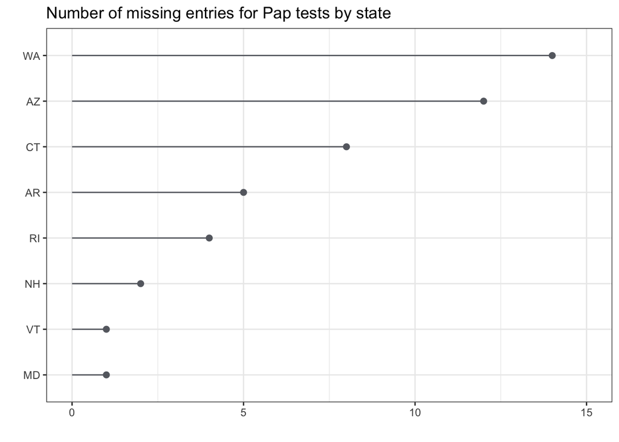

```r
# Visualize missing entries by state
df %>%
    filter(is.na(paptest_crude_prev)) %>%
    count(state_abbr) %>%
    mutate(state_abbr = fct_reorder(state_abbr, n)) %>%
    ggplot(aes(x = state_abbr, y = n)) +
    geom_segment(aes(x = state_abbr, xend = state_abbr, y = 0, yend = n),
                 color = "#666970") +
    geom_point(color = "#666970", size = 2) +
    labs(title = "Number of missing entries for Pap tests by state", x = "", y = "") +
    coord_flip(ylim = c(0, 15)) +
    theme_bw()
```

We identified a known issue. See this notice on the [500 Cities website](https://www.cdc.gov/500cities/index.htm):

> Data about Papanicolaou (Pap) smear use among adult women aged 21-65 years were not available from the 2016 Behavioral Risk Factor Surveillance System for 8 states and therefore not available for 47 cities in those 8 states for the 500 Cities project. The affected states are: Arizona, Arkansas, Connecticut, Maryland, New Hampshire, Rhode Island, Vermont, and Washington. The 500 Cities dataset includes a record for this measure for those 47 cities but it is shown as an empty data cell and it is appropriately footnoted. The interactive map and the map books do not show the Pap test measure for the cities or their census tracts in the 47 cities in these 8 states.

> In previous versions of 500 Cities datasets (released in 2016 and 2017), 6 census tracts from Tucson, Arizona were inadvertently omitted. The datasets have been corrected and users may download them from the 500 Cities Data Portal (https://chronicdata.cdc.gov/browse?category=500+Cities). The updated 500 Cities dataset released in 2018 is unaffected.

# 3 Clean

```r
# Rename state and city variables
df <- df %>%
  rename(state = state_abbr, city = place_name)

# Separate `geolocation` into latitude and longitude
df <- df %>%
  mutate(geolocation = str_replace_all(geolocation, "[() ]", "")) %>%
  separate(geolocation, into = c("lat", "long"), sep = ",") %>%
  mutate(lat = as.numeric(lat), long = as.numeric(long))
```

```r
# Select variables of interest
df <- df %>%
    select(state, city, lat, long, matches("adj_prev"))
```

```r
# Reshape to "long" format
df <- df %>%
  gather(key = "parameter",
         value = "prevalence_adj",
         matches("adj_prev")) %>%
  mutate(parameter = str_replace(parameter,
                                 pattern = "_adj_prev",
                                 replacement = ""))
```

```r
# Keep continental US data
df <- df %>%
  filter(!state %in% c("AK", "HI"))
```

# 4 Save

```r
save(df, file = here("data", "cdc_clean.RData"))
```